# Assignment #3 - AMOD 5250H

Ali Tahsili

**Make sure your solution to each question includes enough output to show that your solution is correct (i.e if asked to create a vector, output the vector afterwards)**

## Question 1 - Two Sample Statistical Tests [9 marks]

Load *salaries.csv*, which contains the average male & female salaries (in 1000s) from 50 random collages in the US, and *BbVsFb.csv*, which contains weights of randomly sampled professional football and basketball players. Note that the two salary columns are dependent data, while the professional player data is independent. For each set of data (note: you are comparing the data within each set, not the sets), complete the following:

1. Test each sample set for normalcy. Summarize the results. [3 marks]

```r
library(rstatix)
(salaries <- read_csv("salaries.csv",
                      col_names=c("males","females"),
                      skip=1,
                      show_col_types = FALSE))
```

| males | females |
| --- | --- |
| 34.5 | 33.9 |
| 30.5 | 31.2 |
| 35.1 | 35.0 |
| 35.7 | 34.2 |
| 31.5 | 32.4 |
| 34.4 | 34.1 |
| 32.1 | 32.7 |
| 30.7 | 29.9 |
| 33.7 | 31.2 |
| 35.3 | 35.5 |

[output cut: 12 more lines]

```r
(salaries <- salaries %>%
    mutate(diff_salary = males - females))
```

| males | females | diff_salary |
| --- | --- | --- |
| 34.5 | 33.9 | 0.59999847 |
| 30.5 | 31.2 | -0.70000076 |
| 35.1 | 35.0 | 0.09999847 |
| 35.7 | 34.2 | 1.50000000 |
| 31.5 | 32.4 | -0.90000153 |
| 34.4 | 34.1 | 0.30000306 |
| 32.1 | 32.7 | -0.60000229 |
| 30.7 | 29.9 | 0.80000114 |
| 33.7 | 31.2 | 2.50000000 |
| 35.3 | 35.5 | -0.20000076 |

[output cut: 12 more lines]

```r
shapiro_test(salaries$diff_salary)
```

| variable | statistic | p.value |
| --- | --- | --- |
| salaries$diff_salary | 0.9317688 | 0.1335606 |

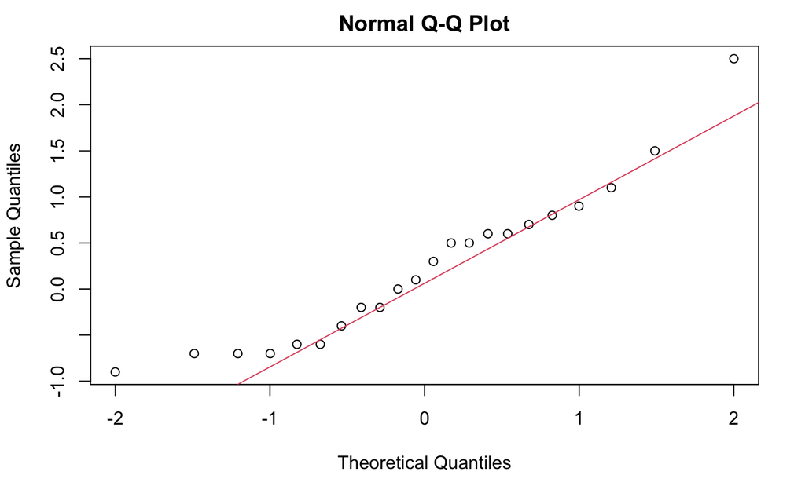

```r
qqnorm(salaries$diff_salary); qqline(salaries$diff_salary, col = 2)
```

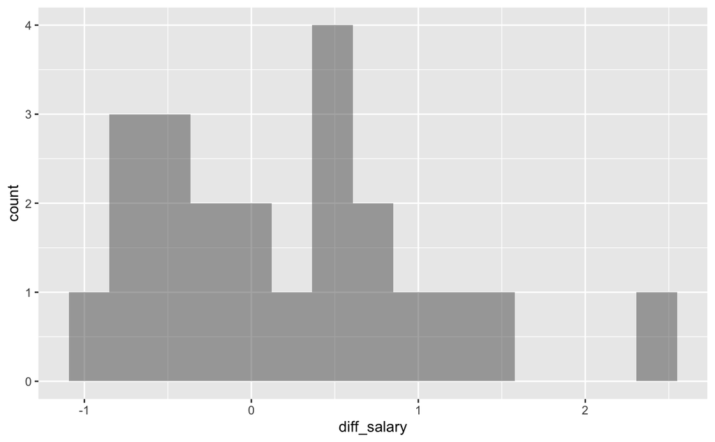

```r
ggplot(salaries, aes(x=diff_salary)) +
  geom_histogram(bins = 15, alpha=1/2)
```

```r
(BbVsFb <- read_csv("BbVsFb.csv",
                    col_names=c("football","basketball"),
                    skip=1,
                    show_col_types = FALSE))
```

| football | basketball |
| --- | --- |
| 245 | 205 |
| 262 | 200 |
| 255 | 220 |
| 251 | 210 |
| 244 | 191 |
| 276 | 215 |
| 240 | 221 |
| 265 | 216 |
| 257 | 228 |
| 252 | 207 |

[output cut: 11 more lines]

```r
(BbVsFb.long <- BbVsFb %>%
    gather(`football`, `basketball`,
           key = "sport",
           value = "weights"))
```

| sport | weights |
| --- | --- |
| football | 245 |
| football | 262 |
| football | 255 |
| football | 251 |
| football | 244 |
| football | 276 |
| football | 240 |
| football | 265 |
| football | 257 |
| football | 252 |

[output cut: 32 more lines]

```r
BbVsFb.long %>%
  group_by(sport) %>%
  shapiro_test(weights)
```

| sport | variable | statistic | p |
| --- | --- | --- | --- |
| basketball | weights | 0.9774148 | 0.9083323 |
| football | weights | 0.9622583 | 0.5627385 |

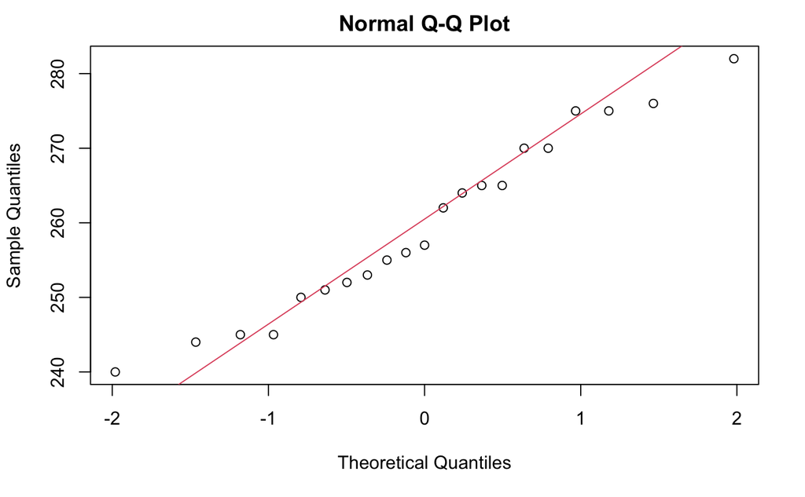

```r
football <- BbVsFb.long$weights[BbVsFb.long$sport == "football"]
basketball <- BbVsFb.long$weights[BbVsFb.long$sport == "basketball"]
qqnorm(football); qqline(football, col = 2)
```

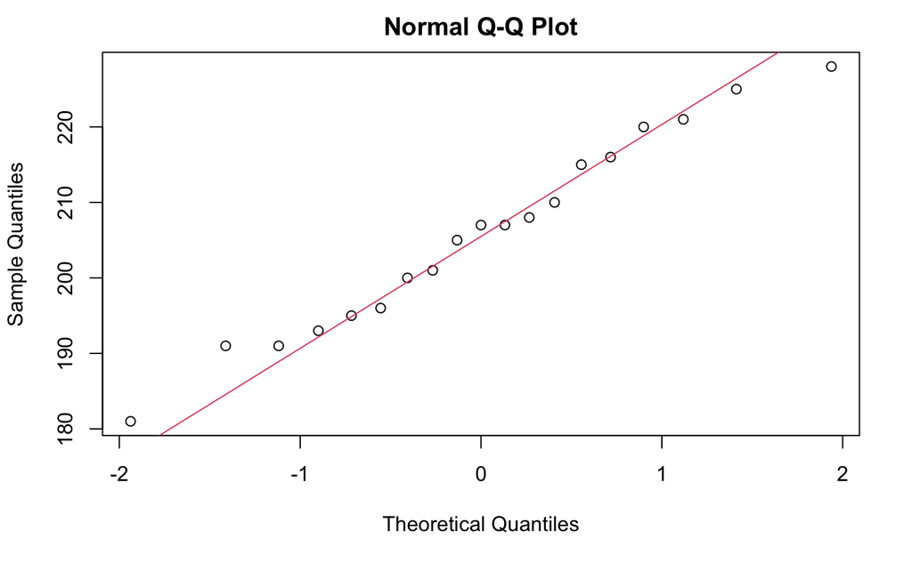

```r
qqnorm(basketball); qqline(basketball, col = 2)
```

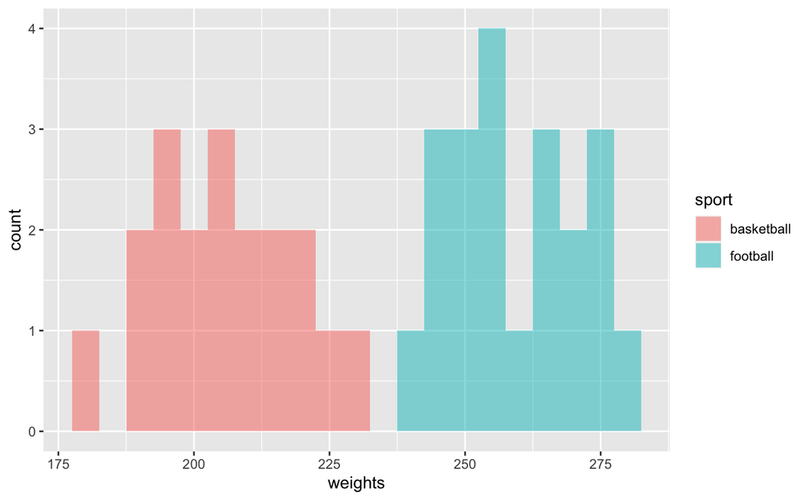

```r
ggplot(BbVsFb.long, aes(x=weights, fill=sport)) +
  geom_histogram(binwidth=5, alpha=1/2)
```

I used gather() to make the data set tidy for the “BbVsFb.csv” data. A Shapiro-Wilk test demonstrated normality by group (p > 0.05). Most observations for each group are approximately in the vicinity of the red line in the normal Q-Q plot. The histogram also shows normality for both football and basketball players.

2. Test to see if the sample variances are significantly different. Explain the results [3 marks]

```r
(salaries.long <- salaries %>%
   gather(males,
          females,
          key = "gender",
          value = "salary") %>%
   select(-diff_salary))
```

| gender | salary |
| --- | --- |
| males | 34.5 |
| males | 30.5 |
| males | 35.1 |
| males | 35.7 |
| males | 31.5 |
| males | 34.4 |
| males | 32.1 |
| males | 30.7 |
| males | 33.7 |
| males | 35.3 |

[output cut: 34 more lines]

```r
(sal.lev <- levene_test(salaries.long, salary ~ gender))
```

| df1 | df2 | statistic | p |
| --- | --- | --- | --- |
| 1 | 42 | 0.002173099 | 0.9630398 |

```r
(BbVsFb.lev <- levene_test(BbVsFb.long, weights ~ sport))
```

| df1 | df2 | statistic | p |
| --- | --- | --- | --- |
| 1 | 38 | 0.01030775 | 0.9196659 |

```r
NA
```

First, I made the “salaries.csv” dataset tidy to implement the Levene test. The test result shows I failed to reject the null hypothesis, and I have insufficient evidence to conclude the sample variances are different, p = 0.96 > 0.05, d = 42. For the “BbVsFb.csv” dataset, I used the same Levene test and again, I failed to reject the null hypothesis, p = 0.92 > 0.05, d = 38. The sample variances for this dataset are the same.

3. Statistically compare the means of each set. What are the results? [3 marks]

```r
(Salary.model <- t_test(salaries.long, salary ~ gender, paired =T))
```

|  | .y. | group1 | group2 | n1 | n2 | statistic | df | p |
| --- | --- | --- | --- | --- | --- | --- | --- | --- |
| 1 | salary | females | males | 22 | 22 | -1.285349 | 21 | 0.213 |

```r
(BbVsFb.model<- t_test(BbVsFb.long, weights ~ sport, var.equal=T))
```

|  | .y. | group1 | group2 | n1 | n2 | statistic | df | p |
| --- | --- | --- | --- | --- | --- | --- | --- | --- |
| 1 | weights | basketball | football | 21 | 21 | -13.64161 | 38 | 3.2e-16 |

```r
NA
```

For the “salaries.csv” dataset, I failed to reject the null hypothesis. As a result, mean salaries was not statistically different by gender, t(21) = -1.29, p = 0.213 > 0.05.

For the “BbVsFb.csv” dataset, I can reject the null hypothesis and conclude that the mean difference in weight between basketball and football players in the sample was statistically significant, t(38) = -13.64, p = 3.2^{-16}, with football players tending to weigh more than basketball players.

## Question 2 - Linear Regresssion [10 marks]

Load *Insurance.csv*, which contains auto insurance information for regions Sweden. Where `X = number of claims` and `Y = total payment for all the claims in thousands` (Swedish Kronor).

1. Use summary and plot to investigate the data. Identify anything worth noting. [2 marks]

```r
(insurance <- read_csv("insurance.csv",
                       col_names=c("number_of_claims","total_payments"),
                       skip=1,
                       show_col_types = FALSE))
```

| number_of_claims | total_payments |
| --- | --- |
| 108 | 392.5 |
| 19 | 46.2 |
| 13 | 15.7 |
| 124 | 422.2 |
| 40 | 119.4 |
| 57 | 170.9 |
| 23 | 56.9 |
| 14 | 77.5 |
| 45 | 214.0 |
| 10 | 65.3 |

[output cut: 53 more lines]

```r
summary(insurance)
```

```
 number_of_claims total_payments
 Min.   :  0.0    Min.   :  0.00
 1st Qu.:  7.5    1st Qu.: 38.85
 Median : 14.0    Median : 73.40
 Mean   : 22.9    Mean   : 98.19
 3rd Qu.: 29.0    3rd Qu.:140.00
 Max.   :124.0    Max.   :422.20
```

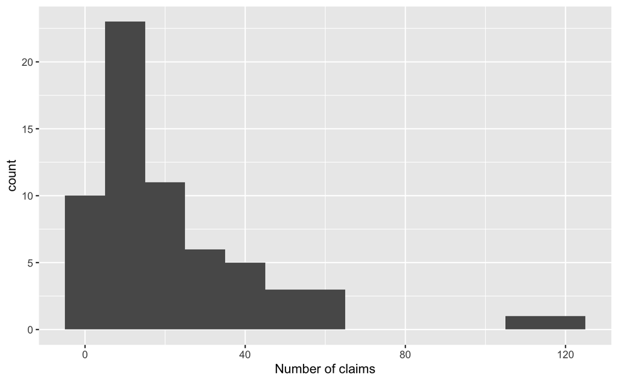

```r
insurance %>%
  ggplot() +
  aes(x = number_of_claims) +
  geom_histogram(binwidth = 10) +
  xlab("Number of claims")
```

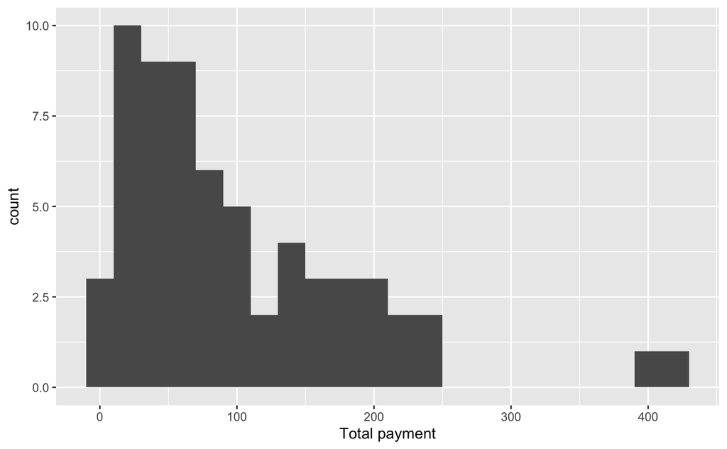

```r
insurance %>%
  ggplot() +
  aes(x = total_payments) +
  geom_histogram(binwidth = 20) +
  xlab("Total payment")
```

```r
cor(insurance$total_payments,insurance$number_of_claims)
```

```
[1] 0.9128782
```

The correlation 0.91 shows there is a strong positive linear correlation. As the number claims increases, the total payments tend to increase.

2. Perform a simple linear regression to generate a model for the relationship. [1 mark]

```r
(relation <- (lm(total_payments ~ number_of_claims, data = insurance)))
```

```
Call:
lm(formula = total_payments ~ number_of_claims, data = insurance)

Coefficients:
     (Intercept)  number_of_claims
          19.994             3.414
```

3. Plot the model for evaluation and summarize the results. [3 marks]

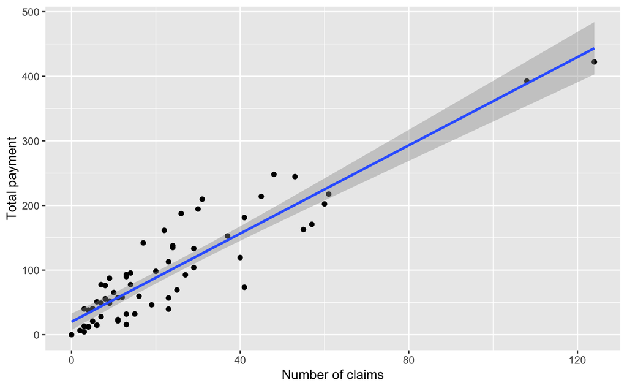

```r
insurance %>%
  ggplot() +
  aes(x = number_of_claims, y = total_payments) +
  geom_point() +
  geom_smooth(method = lm) +
  xlab("Number of claims") +
  ylab("Total payment")
```

Most observations have less than forty claims. There are two observation which have more than 100 claims. There is a strong positive relationship between total payments and the number of claims, and the standard deviation slightly rises as the number of claims increases.

4. Output the summary of your model and explain the relevant things it tells you. Use inline r-markdown where relevant. [3 marks]

```r
(summary_relation <- summary(relation))
```

```
Call:
lm(formula = total_payments ~ number_of_claims, data = insurance)

Residuals:
    Min      1Q  Median      3Q     Max
-86.561 -24.051  -0.347  23.432  83.977

Coefficients:
                 Estimate Std. Error t value Pr(>|t|)
(Intercept)       19.9945     6.3678    3.14   0.0026 **
number_of_claims   3.4138     0.1955   17.46   <2e-16 ***
---
Signif. codes:  0 ‘***’ 0.001 ‘**’ 0.01 ‘*’ 0.05 ‘.’ 0.1 ‘ ’ 1

Residual standard error: 35.94 on 61 degrees of freedom
Multiple R-squared:  0.8333,    Adjusted R-squared:  0.8306
F-statistic:   305 on 1 and 61 DF,  p-value: < 2.2e-16
```

The residual median is -0.347, which is around zero. It shows we do not have a bias in our model.

The total payment is 20 when there are no claims. Since we expect no pay for no claim, this estimate is not very useful.

For every ten additional claims increase, we would expect the total payments to increase on average by 34.

The number of claims explains 83.06% of the variability in the total payment.

5. Use the model to predict the total claim, if the number of accidents is 80 and 150. [1 marks]

```r
newData <- tibble(number_of_claims = c(80, 150))
predict(relation, newData)
```

```
       1        2
293.1004 532.0680
```

## Question 3 - Stringr [10 marks]

1. The *babynames* library that was loaded at the top of the document contains a *babynames* dataframe. Examine this dataframe (so you know what’s in it) and filter it so that your resulting dataframe (which you’re going to use for the rest of this question) contains only the names from the year you were born. Output the first 5 rows of you new data frame.

```r
babynames_1988 <- babynames %>%
  filter(year == 1988)
babynames_1988 %>%
  head(5)
```

| year | sex | name | n | prop |
| --- | --- | --- | --- | --- |
| 1988 | F | Jessica | 51538 | 0.02680669 |
| 1988 | F | Ashley | 49961 | 0.02598643 |
| 1988 | F | Amanda | 39455 | 0.02052190 |
| 1988 | F | Sarah | 28366 | 0.01475413 |
| 1988 | F | Jennifer | 27887 | 0.01450499 |

```r
NA
```

2. Using stringr and your new dataframe, calculate the mean length of all girl names, and compare it to the mean length of all boys names.

```r
Fem_babynames_1988 <- babynames_1988 %>%
  filter(sex == "F")

mean(str_length(Fem_babynames_1988$name))
```

```
[1] 6.460042
```

```r
Male_babynames_1988 <- babynames_1988 %>%
  filter(sex == "M")

mean(str_length(Male_babynames_1988$name))
```

```
[1] 6.103099
```

3. Extract the first letter of each girls name (into a new vector) then use `table` to get a count of each letter. Do the same for the boys names.

```r
str_extract(Fem_babynames_1988$name, "^.") %>%
  table()
```

```
.
   A    B    C    D    E    F    G    H    I    J    K    L    M    N    O    P    Q    R    S
1238  490 1170  822  386  167  237  177  132 1110 1259 1051 1117  454   66  189   60  622 1635
   T    U    V    W    X    Y    Z
1021   12  162   66   14  145   75
```

```r
str_extract(Male_babynames_1988$name, "^.") %>%
  table()
```

```
.
  A   B   C   D   E   F   G   H   I   J   K   L   M   N   O   P   Q   R   S   T   U   V   W
696 371 592 795 297 145 270 217  92 899 545 406 567 244 121 150  48 546 488 547  32 100 126
  X   Y   Z
 12  90  91
```

4. Find all girls names that contain ‘zz’ (you can just display the names)

```r
str_view(Fem_babynames_1988$name,"zz|Zz", match = T)
```

[interactive chart not shown]

```r
NA
```

5. Display the entire row in the dataframe for all boys names that contain ‘zz’

```r
Male_babynames_1988 %>%
  filter(str_detect(Male_babynames_1988$name,"zz|Zz"))
```

| year | sex | name | n | prop |
| --- | --- | --- | --- | --- |
| 1988 | M | Chazz | 37 | 1.849e-05 |
| 1988 | M | Ozzie | 23 | 1.149e-05 |
| 1988 | M | Jazz | 13 | 6.500e-06 |
| 1988 | M | Ozzy | 12 | 6.000e-06 |
| 1988 | M | Jazzman | 7 | 3.500e-06 |
| 1988 | M | Shabazz | 7 | 3.500e-06 |
| 1988 | M | Ezzard | 5 | 2.500e-06 |

```r
NA
```

6. Create vector containing 5 full names (first and last). Using stringr functions to output each name as first initial - period - last name. (i.e. Jamie Mitchell -> J. Mitchell). This should be a vectorized solution (no looping).

```r
full_names <- c("Ali Tahsili",
                "James Ford",
                "Thomas Edison",
                "Henry Hamilton",
                "Jessica Martinez")

str_replace(full_names, "([^ ]+)",
            str_c(str_extract(full_names,"^."),"."))
```

```
[1] "A. Tahsili"  "J. Ford"     "T. Edison"   "H. Hamilton" "J. Martinez"
```

## Question 4 - Twitter [15 marks]

**Note: because of the transient nature of Twitter, you’ll never be able to pull the same data twice. Please do your data collection in an R Script, and save the resulting dataframe to a file. Include your code in the un-executing block below so I can see it…but the Markdown file should load your collected data from the file(s) you created.**

Go to Twitters search page (https://twitter.com/search-home?lang=en) and find something interesting to you that is currently trending.

In a separate R Script, use the rTweet library to access Twitter’s REST API and pull any historical tweets with that hashtag.

Then use Twitters Streaming API to collect real-time tweets with the same hashtag for several hours (at least 3).

Parse both collections into dataframes and add a variable indicating which method it was collected with. Then combine the data frames into one. Export this to a file, and include all your code in the un-executing block below.

Import the data from the file you created and use this data frame and the tidy text library to do some relevant text analysis (this should include cleaning, tokenizing, frequencies, and a couple of interesting graphs).

You are expected to describe your analysis. Don’t just include results with no explanation.

*Note: you are expected to creatively chose your own analysis. Repeating the things demonstrated in the slides will get you at most part marks*.

```r
# Looked for "#BallonDor" on Twitter before the ceremony date.
BallonDor_Hashtag <- search_tweets("#BallonDor",
                             n = 100000,
                             include_rts = FALSE,
                             language = "en",
                             until= "2021-11-29",
                             retryonratelimit = TRUE)

# Since it was not enough tweet of the hashtag, I searched for the word itself: "Ballon d'Or".
BallonDor_NoHashtag <- search_tweets("Ballon d'Or",
                                 n = 100000,
                                 include_rts = FALSE,
                                 language = "en",
                                 until= "2021-11-29",
                                 retryonratelimit = TRUE)

# I used the union function to join these two data frames and did not include
# the common observation.
BallonDor_Historic<- union(BallonDor_Hashtag,BallonDor_NoHashtag)

# Removed unused data frames to save space.
rm(BallonDor_Hashtag, BallonDor_NoHashtag)

# Saved the time of announcing the winner of Ballon d'Or.
winner_time <- ymd_hms("2021-11-29 20:53:00")

# removed any data after announcing the winner.
BallonDor_Historic <- BallonDor_Historic %>%
  filter(created_at < winner_time)

# 40046 data extracted before announcing time.
# Added a variable indicating which method it was collected with.
BallonDor_Historic <- BallonDor_Historic %>% mutate(Collect_Method = "REST")


# Streamed the data after announcing the winner and saved it to json file.
stream_tweets("#BallonDor",
              language = "en",
              include_rts = FALSE,
              timeout = 60*60*3,
              file_name = "BallonDor.json",
              parse = FALSE)

# Let's parse the json file.
# BallonDor_Stream <- parse_stream("BallonDor.json")
# I got an error: parse error: unallowed token at this point in JSON text
# This error showed up because while it collected streaming data, inconsistent internet connection resulted in tweet objects containing unintended carriage returns. So, I used recover_stream() function from the below source.
# https://gist.githubusercontent.com/JBGruber/dee4c44e7d38d537426f57ba1e4f84ab/raw/ce28d3e8115f9272db867158794bc710e8e28ee5/recover_stream.R
BallonDor_Stream <- recover_stream("BallonDor.json")

# There was an interactive question popped up:
# There were 54306 tweets with problems. Should they be copied to your working directory?
# I chose 3 which was "copy a list with status_ids" selection.
# Then I assigned all the broken tweets in broken_tweets data frame.
broken_tweets <- rtweet::lookup_statuses(readLines("broken_tweets.txt"))

# Then I combined the BallonDor_Stream and broken_tweets together.
BallonDor_Stream_complete <- bind_rows(BallonDor_Stream,broken_tweets)

# Removed unused data frames to save space.
rm(broken_tweets, BallonDor_Stream)

# Added a variable indicating which method it was collected with.
BallonDor_Stream_complete <- BallonDor_Stream_complete %>% mutate(Collect_Method = "Streamed")

# removed any data before announcing the winner.
BallonDor_Stream_complete <- BallonDor_Stream_complete %>%
  filter(created_at >= winner_time)

# 222183 data have being streamed after announcing the winner
# Combined the streaming and historic data together.
BallonDor <- bind_rows(BallonDor_Historic,BallonDor_Stream_complete)

# Removed unused data frames to save space
rm(BallonDor_Historic, BallonDor_Stream_complete)

# Selected 15 variables which are useful for my the analysis.
BallonDor <- BallonDor %>% select(user_id, status_id, created_at, screen_name,
                                     text, source, Collect_Method, favorite_count,
                                     retweet_count, reply_count, country, url,
                                     country_code, followers_count, verified,
                                     followers_count)

# Saved BallonDor to RData file to load it later.
save(BallonDor, file = "BallonDor.RData")
```

### REST vs. Stream?

```r
# First, let's load the data.
load("BallonDor.RData")

# Let's see how many tweets are collected from streaming and REST each.
(n_collect <- BallonDor %>% count(Collect_Method))
```

| Collect_Method | n |
| --- | --- |
| REST | 40046 |
| Streamed | 222183 |

```r
NA
```

There are about 5.5 times tweets collected from streaming compared to REST API. Because the #BallonDor trends a lot during and after the ceremony.

### How many tweets by each source?

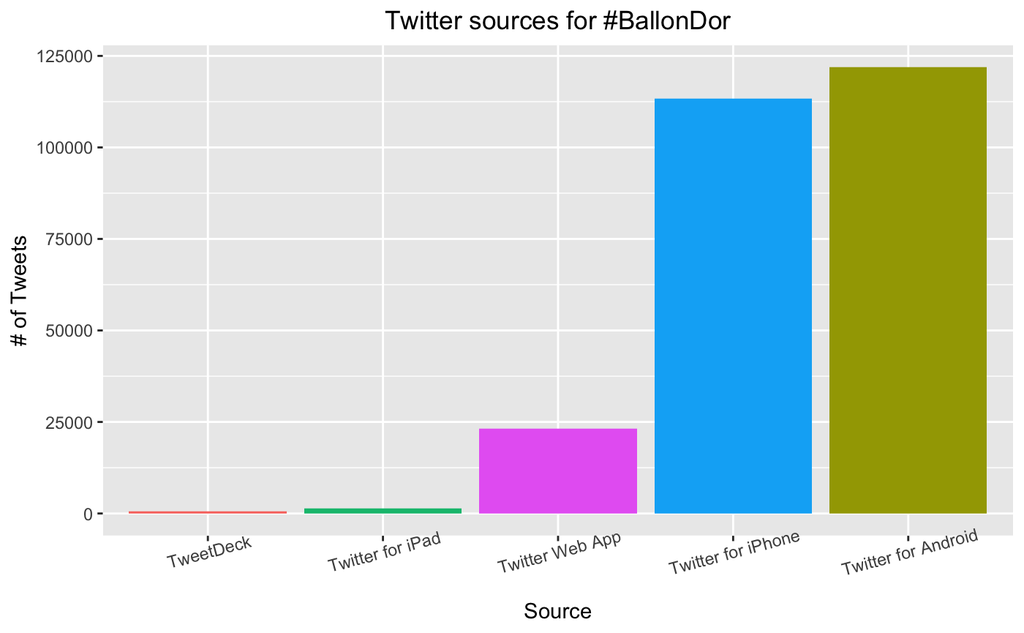

```r
tweet_source <- BallonDor %>%
  group_by(source) %>%
  count(sort = T) %>%
  head(5)

tweet_source %>%
  ggplot() +
  # reordered sources by the number of tweets
  aes(reorder(source, n), n, fill = source) +
  geom_bar(stat = "identity") +
  labs(title = "Twitter sources for #BallonDor") +
  xlab("Source") +
  ylab("# of Tweets") +
  theme(plot.title = element_text(hjust = 0.5),
        axis.text.x = element_text(angle = 15),
        legend.position="none")
```

Most of the tweets for #BallonDor came from Android devices following by iPhone and Web App.

### What are the most used words for #BallonDor Tweets?

```r
common.words <- BallonDor %>%
  select(text) %>%
  unnest_tokens(word,
                text,
                token = "tweets") %>%
  filter(!word %in% stop_words$word,
         !word %in% str_remove_all(stop_words$word, "'"),
         str_detect(word, "[a-z]"))
```

```
Using `to_lower = TRUE` with `token = 'tweets'` may not preserve URLs.
```

```r
most.frequency <- common.words %>%
  count(word, sort = TRUE)

most.frequency %>%
  head(200)
```

| word | n |
| --- | --- |
| #ballondor | 203267 |
| messi | 95140 |
| ballon | 85398 |
| dor | 84219 |
| lionel | 43186 |
| winner | 33053 |
| lewandowski | 27559 |
| award | 24958 |
| robert | 22088 |
| #messi | 19851 |

[output cut: 190 more lines]

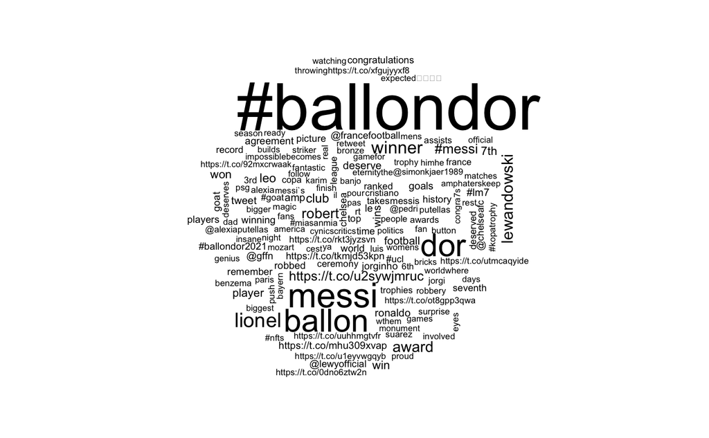

```r
common.words%>%
  count(word) %>%
  with(wordcloud(word, n, max.words = 150))
```

### Investigating some interesting words in BallonDor data frame.

#### Investigating The link “https://t.co/u2sywjmruc” 11th word

```r
# Investigated what tweets related to number 11 most used word which is a link: https://t.co/u2sywjmruc
BallonDor %>%
  filter(str_detect(text, "https://t.co/u2sywjmruc")) %>%
  select(text)
```

| text |
| --- |

```r
NA
```

There are no tweet texts, including that link. So, it is maybe something wrong happened during the unnesting process.

#### Investigating the 20th most used word: deserve

```r
# "deserve" word (20th)
deserve <- BallonDor %>%
  select(text) %>%
  filter(str_detect(text, "deserve")) %>%
  unnest_tokens(word,
                text,
                token = "tweets") %>%
  filter(!word %in% stop_words$word,
         !word %in% str_remove_all(stop_words$word, "'"),
         str_detect(word, "[a-z]")) %>%
  count(word, sort = TRUE)
```

```
Using `to_lower = TRUE` with `token = 'tweets'` may not preserve URLs.
```

```r
deserve %>% head(200)
```

| word | n |
| --- | --- |
| robert | 16977 |
| #ballondor | 13284 |
| messi | 11209 |
| lewandowski | 11130 |
| ballon | 10272 |
| dor | 10233 |
| deserve | 9859 |
| award | 8443 |
| #messi | 7949 |
| agreement | 7536 |

[output cut: 190 more lines]

It is fascinating that in Tweets containing “deserve”, Robert is the most used word and Messi got the third place. This result may show that many people think Robert Lewandowski deserved more to get the award than Messi. So, we should investigate the verb “not deserve” and check which football player got the first place.

#### Investigating “not deserve”

```r
# "not deserve" word
(not_deserve <- BallonDor %>%
  select(text) %>%
   # I took into account the "don't deserve" and "doesn't deserve" as well.
  filter(str_detect(text, "not deserve")|str_detect(text, "n't deserve")) %>%
    head(100))
```

| text |
| --- |
| When someone says Lionel Messi doesn't deserve the Ballon d'or:\n\n#BallonDor2021 \n#BallonDor \n#Messi \n#Lewandowski \n#Benzema \n#Barca \n#Ronaldo https://t.co/jxKqhjSjhY |
| Lewandowski deserves the Ballon d'Or and others do not deserve it👈 @lewy_official #ballondor https://t.co/NTYP76RdWO |
| This is what happens when you have no PR.\nMessi don't give a fck about Ballon d'Or as he already said but that doesn't mean he don't deserve it Matter of fact he deserves it the most.\nBut sadly he d… |
| @Pharezsnr @moses_aneti @WehliyeMohamed Messi has had a shit season/year compared to Lewandowski, Salah, Benzema or even CR7. Messi doesn't deserve it this year. If he wins then #BallonDor is a joke a… |
| Somehow she finished 21st in https://t.co/pwMt8MTKsB and we are to believe she doesn't deserve a top 3 in #BallonDor or FIFA rankings?? \nIn addition \nGolden boot\nHattrick in a final\nLead her team … |
| if anyone thinks Messi doesn't deserve the #ballondor then even the doctor cant help you. |
| Lionel Messi does not deserve to win the ballon d'or... absolute robbery. Too much politics involved in this French qatari pr company. |
| he doesn't deserve the ballon d'Or because Lewandowski has been pumping goals in from 2 yards out every week on a platter of gold https://t.co/tJGYjK8FOm |
| @Denzo_CFC I'm gonna have to disagree on this one, been brilliant for many years, but doesn't deserve to win the ballon d'or, if it was the premier league then that would've been a different story, bu… |
| @cristiano_peak He's a brilliant player but for the past few years everybody knows that he doesn't deserved it.. Players like lewandowski,kante,van dijk, even Ronaldo when they gave it to Luca modric.… |

[output cut: 90 more lines]

```r
not_deserve <- BallonDor %>%
  select(text) %>%
  filter(str_detect(text, "not deserve")|str_detect(text, "n't deserve")) %>%
  unnest_tokens(word,
                text,
                token = "tweets") %>%
  filter(!word %in% stop_words$word,
         !word %in% str_remove_all(stop_words$word, "'"),
         str_detect(word, "[a-z]")) %>%
  count(word, sort = TRUE)
```

```
Using `to_lower = TRUE` with `token = 'tweets'` may not preserve URLs.
```

```r
not_deserve %>%
  head(200)
```

| word | n |
| --- | --- |
| deserve | 525 |
| messi | 401 |
| #ballondor | 267 |
| ballon | 228 |
| dor | 219 |
| award | 106 |
| lewandowski | 86 |
| win | 76 |
| won | 60 |
| football | 59 |

[output cut: 190 more lines]

At first, I gathered some tweet texts that included “not deserve”. Several people seemed angry about Lewandowski not winning an award. Also, in the table we can see, the word “Messi” has been used the most in tweets that mentioned, “not deserve”! Wow!!! Let’s see which words used before and after deserve. I used ngrams method for analyzing that.

#### Implementing ngrams for analysing “deserve” further

```r
deserve_bigram <- BallonDor %>%
  unnest_tokens(bigram, text, token = "ngrams", n = 5) %>%
  count(bigram, sort = TRUE) %>%
    filter(str_detect(bigram, "deserve"))

deserve_bigram %>%
  head(200)
```

| bigram | n |
| --- | --- |
| deserve your ballon d'or last | 7158 |
| you deserve your ballon d'or | 7158 |
| robert you deserve your ballon | 7046 |
| lewandowski robert you deserve your | 7032 |
| robert lewandowski robert you deserve | 7029 |
| he deserved it last year | 823 |
| deserved it last year and | 817 |
| i think he deserved it | 809 |
| lie i think he deserved | 809 |
| think he deserved it last | 809 |

[output cut: 190 more lines]

```r
NA
```

This ngrams also confirms the fact that many people believe Robert Lewandowski deserved the Ballon d’Or award.

#### Investigating “robbed” (word 30th)

```r
robbed <- BallonDor %>%
  select(text) %>%
  filter(str_detect(text, "robbed"))

robbed %>%
  head(100)
```

| text |
| --- |
| If Messi wins, messi deserves.\nIf the Ballon d'or was based on goals and assists per year then Messi has been robbed way more than Lewandowski.\n#LM7 #BallonDor2021 #BallondOr \n#Seventh |
| Lewandowski robbed #BallonDor https://t.co/VL1BemfVfr |
| Dubai D’Or’s fan boys on their way to say, “Lewi robbed” \n Cry more!!\n#BallondOr #Messi #Messi7 |
| It's #official @lewy_official #lewandowski has won the #BallondOr the editor in chief of #france #football has confirmed it...\n#Messi has been robbed once again. Victim of his own high standards. |
| Now is the time to print your Lewandowski was robbed t-shirt. #BallonDor |
| Lewandowski is going to be robbed second year in a row\n\n#BallondOr |
| @francefootball Suddenly, last year, the award was cancelled because "would be 'not worthy' of the trophy's history".Pandemic is still on and more players got the virus this year and there will be a c… |
| As we all know if Ballon d'Or was about the best player Messi will win it every year but sadly it's about the numbers &amp; PR.\nMessi don't care about it. Me neither but he deserves it!\nThe award be… |
| They really robbed Messi of Ballon d'Or this year huh?\nHe was literally the best compared to others with winning Copa America, being the top scorer &amp; player of the tournament with Pichichi &amp; … |
| With his first Hat-trick of assists for PSG, Messi have made yet another average manager look like a world class one.\nToo bad he got robbed of Ballon d'Or yet again despite being the most deserving o… |

[output cut: 90 more lines]

```r
robbed <- BallonDor %>%
  select(text) %>%
  filter(str_detect(text, "robbed")) %>%
  unnest_tokens(word,
                text,
                token = "tweets") %>%
  filter(!word %in% stop_words$word,
         !word %in% str_remove_all(stop_words$word, "'"),
         str_detect(word, "[a-z]")) %>%
  count(word, sort = TRUE)
```

```
Using `to_lower = TRUE` with `token = 'tweets'` may not preserve URLs.
```

```r
robbed %>%
  head(200)
```

| word | n |
| --- | --- |
| robbed | 6523 |
| #ballondor | 5199 |
| lewandowski | 3920 |
| messi | 2751 |
| ballon | 2460 |
| dor | 2417 |
| ronaldo | 1924 |
| watching | 1733 |
| https://t.co/3sk0n8x2kv | 1589 |
| award | 685 |

[output cut: 190 more lines]

The result that came from filtering “robbed” showed that many people believed Lewandowski was robbed due to the decision of the Ballon d’Or ceremony. In addition, the table showed Lewandowski was the first in the Tweets related to the word robbed. This result confirms the conclusion from the word “deserve”.

### Most used word in REST vs. Stream method.

```r
freq.before.after <- BallonDor %>%
  select(text, Collect_Method) %>%
  unnest_tokens(word,
                text,
                token = "tweets") %>%
  filter(!word %in% stop_words$word,
         !word %in% str_remove_all(stop_words$word, "'"),
         str_detect(word, "[a-z]")) %>%
  group_by(Collect_Method) %>%
  count(word, sort = TRUE) %>%
  # rate_n is n/(# of each collecting method)
  mutate(rate_n = case_when(Collect_Method == "REST" ~ n/n_collect$n[1],
                            TRUE                    ~ n/n_collect$n[2]))
```

```
Using `to_lower = TRUE` with `token = 'tweets'` may not preserve URLs.
```

```r
freq.before.after %>%
  arrange(desc(rate_n)) %>%
  head(40)
```

| Collect_Method | word | n | rate_n |
| --- | --- | --- | --- |
| Streamed | #ballondor | 195264 | 0.87884312 |
| REST | ballon | 34375 | 0.85838785 |
| REST | dor | 33144 | 0.82764820 |
| Streamed | messi | 81271 | 0.36578406 |
| REST | messi | 13869 | 0.34632672 |
| Streamed | dor | 51075 | 0.22987807 |
| Streamed | ballon | 51023 | 0.22964403 |
| REST | #ballondor | 8003 | 0.19984518 |
| Streamed | lionel | 41673 | 0.18756160 |
| REST | le | 7334 | 0.18313939 |

[output cut: 30 more lines]

```r
NA
NA
```

The impressive part is that Messi was mentioned after and before the ceremony more than Lewandowski, and this is obvious because Messi is much more famous than Lewandowski.

### Verified accounts

```r
most_word_verified <- BallonDor %>%
  filter(verified == T) %>%
  select(text,
         created_at,
         Collect_Method) %>%
  unnest_tokens(word,
                text,
                token = "tweets") %>%
  filter(!word %in% stop_words$word,
         !word %in% str_remove_all(stop_words$word, "'"),
         str_detect(word, "[a-z]"))
```

```
Using `to_lower = TRUE` with `token = 'tweets'` may not preserve URLs.
```

```r
most_word_verified %>%
  count(word, sort = TRUE) %>%
  head(100)
```

| word | n |
| --- | --- |
| #ballondor | 1287 |
| ballon | 740 |
| dor | 703 |
| messi | 585 |
| lionel | 342 |
| lewandowski | 244 |
| robert | 177 |
| winner | 173 |
| win | 161 |
| award | 158 |

[output cut: 90 more lines]

```r
NA
```

In verified accounts Messi was tweeted more than any other players.

### Sentiment analysis

#### Get the sentiments

```r
bing <- get_sentiments("bing")
save(bing, file = "bing.RData")

# "This application/product/tool makes use of the NRC Word-Emotion Association Lexicon, created by {Mohammad, Saif M. and Turney, Peter D.} at the National Research Council Canada."
# URL: http://saifmohammad.com/WebPages/lexicons.html
nrc <- get_sentiments("nrc")
save(nrc, file = "nrc.RData")

# "This application/product/tool makes use of the AFINN-111.
# URL: http://www2.imm.dtu.dk/pubdb/views/publication_details.php?id=6010
afinn <- get_sentiments("afinn")
save(afinn, file = "afinn.RData")
```

#### Sentiment (bing library)

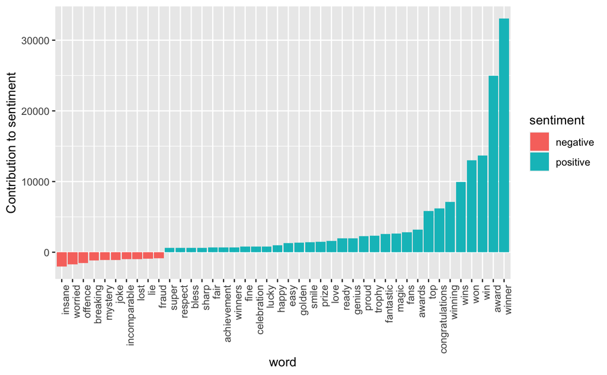

```r
bing.sentiment.counts <- most.frequency %>%
                inner_join(bing) %>%
  # Only filtered in with more than 600 counts
  filter(n > 600) %>%
  # Put positive words in positive axis and negative words in negative axis
  mutate(n = ifelse(sentiment == "negative", -n, n)) %>%
  mutate(word = reorder(word, n)) %>%
  ggplot(aes(word, n, fill = sentiment)) +
  geom_bar(stat = "identity") +
  theme(axis.text.x = element_text(angle = 90, hjust = 1)) +
  ylab("Contribution to sentiment")
bing.sentiment.counts
```

Most of the words are positive because they were related to the Ballon d’Or ceremony, and this result would be expected. Words “winner”, “award”, “win”, “won”, “wins”, “winning” and so on are have the most used in our dataset joined with bing sentiment library. I will filter these words to have a better sight.

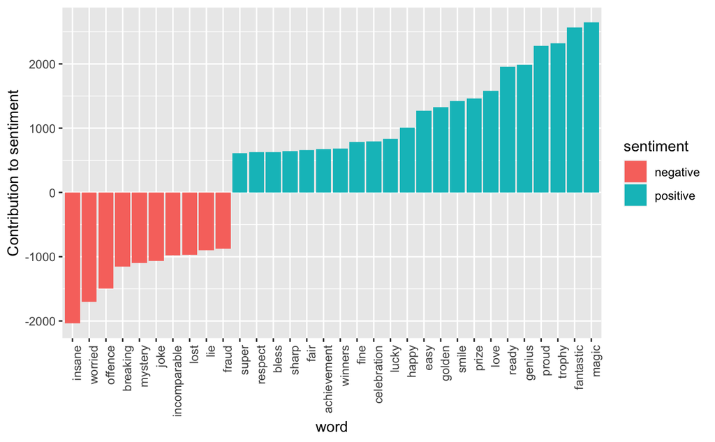

```r
myStopWords <- c("win","winner","award","winning", "won", "wins", "congratulations","top","awards","fans")
bing.sentiment.counts.trimmed <- most.frequency %>%
                inner_join(bing) %>%
  # Only filtered in with more than 600 counts
  filter(n > 600) %>%
  filter (!word %in% myStopWords) %>%
  # Put positive words in positive axis and negative words in negative axis
  mutate(n = ifelse(sentiment == "negative", -n, n)) %>%
  mutate(word = reorder(word, n)) %>%
  ggplot(aes(word, n, fill = sentiment)) +
  geom_bar(stat = "identity") +
  theme(axis.text.x = element_text(angle = 90, hjust = 1)) +
  ylab("Contribution to sentiment")
bing.sentiment.counts.trimmed
```

After filtering `myStopWords`, the diagram shows the word “insane” repeated about 2000 times following with “worried”, “offence” and “breaking” with less than 2000 times in negative words. “Magic”, “fantastic”, “trophy” and “proud” are tweeted more than 2000 times in positive words.

#### Sentiment (nrc library)

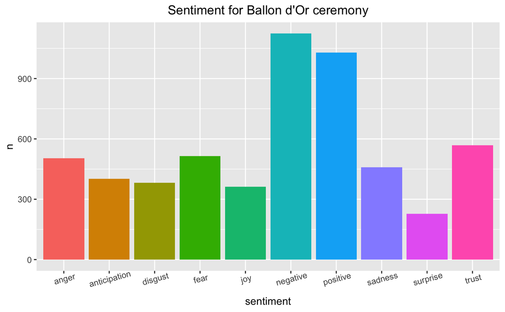

```r
# barchart plotted to show ten sentiment from nrc library
most.frequency %>%
  inner_join(nrc) %>%
  count(sentiment, sort=TRUE)%>%
  ggplot(aes(sentiment, n, fill=sentiment)) +
  geom_bar(stat = "identity") +
  labs(title = "Sentiment for Ballon d'Or ceremony") +
  theme(plot.title = element_text(hjust = 0.5),
        axis.text.x = element_text(angle = 15),
        legend.position="none")
```

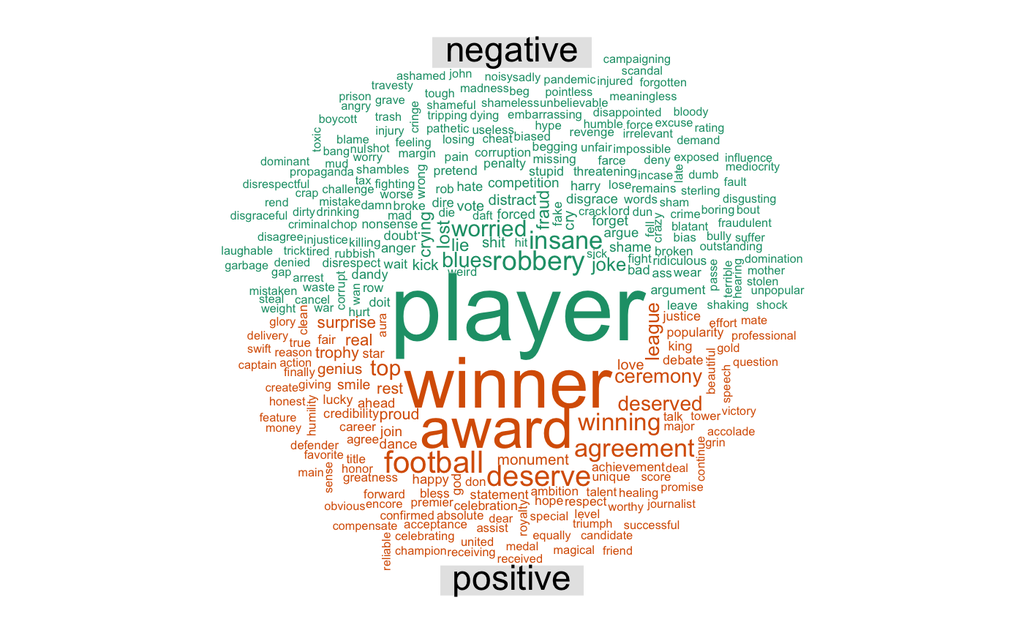

```r
# Separated positive and negative sentiment from other sentiments
common.words %>%
  inner_join(nrc) %>%
  filter(sentiment %in% c("positive",
                          "negative")) %>%
  count(word,sentiment, sort=TRUE) %>%
  acast(word ~ sentiment, value.var = "n", fill = 0) %>%
  comparison.cloud(colors = brewer.pal(8, "Dark2"),
                   title.size=1.5, max.words=300)
```

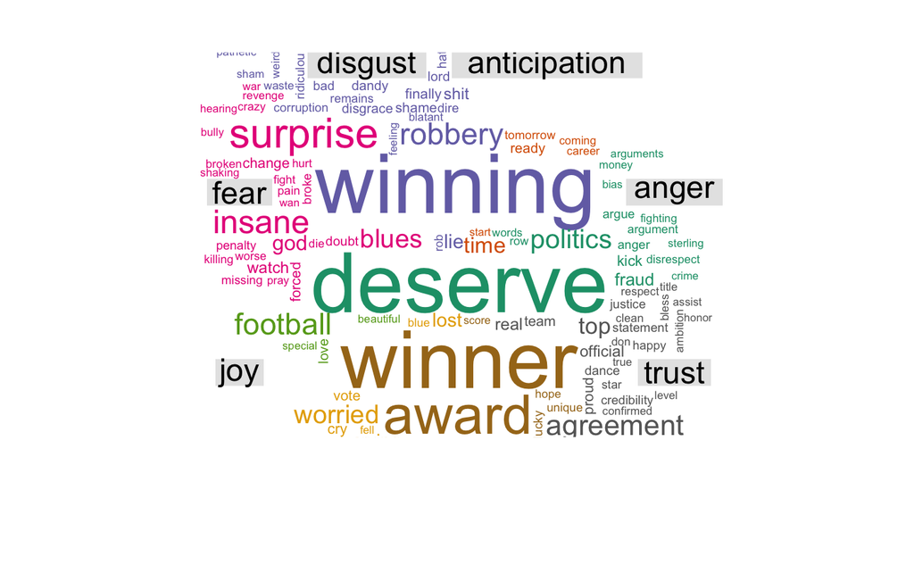

```r
# Positive and negative sentiment filtered
common.words %>%
  inner_join(nrc) %>%
  filter(!sentiment %in% c("positive",
                          "negative")) %>%
  count(word,sentiment, sort=TRUE) %>%
  acast(word ~ sentiment, value.var = "n", fill = 0) %>%
  comparison.cloud(colors = brewer.pal(8, "Dark2"),
                   title.size=1.5, max.words=140)
```

The bar chart showed most of the words tweeted in with negative sentiment. So, I plotted the word of cloud to see why. The term “player” is used so much and has a negative meaning in this lexicon; however, the player here means a football player. Looking at the other sentiments in the bar chart and word of cloud, we can see “trust” has the most frequency followed by “fear” and “anger”.

#### Sentiment (afinn library)

```r
(afinn.sentiment <- most.frequency %>%
    inner_join(afinn, by = "word") %>%
    mutate(n_times_value = n*value))

(sum.value <- afinn.sentiment %>%
    summarise(sum(n_times_value)))

(sum.words <- afinn.sentiment %>%
    summarise(sum(n)))

# average value for all the tweets:
(avg.value.tweets <- as.numeric(sum.value/sum.words))
```

[output not shown]

The afinn lexicon assigns words with a score that runs between -5 and 5, with negative scores indicating negative sentiment and positive scores indicating positive sentiment. I calculated the average value for all the words related to the Ballon d’Or ceremony. To do that, I sorted words by their counts and created a new column which is the multiple of the count and its value. Then I summed all the values and divided them by the sum of all the words. The result was 2.16, which showed that the feedback from the ceremony was positive from one week before the ceremony to 3 hours after the ceremony.

### Bigram network

#### Creat a sorted bigram

```r
bigram_words <- BallonDor %>%
  select(text) %>%
  unnest_tokens(
    input = text,
    output = bigram,
    token = 'ngrams',
    n = 2) %>%
  count(bigram, sort = T)

bigram_words %>%
  head(50)
```

| bigram | n |
| --- | --- |
| https t.co | 176343 |
| ballondor https | 103266 |
| ballon d'or | 42116 |
| lionel messi | 40983 |
| ballon d’or | 40131 |
| messi ballondor | 36310 |
| is the | 28311 |
| the ballondor | 26601 |
| of the | 25572 |
| for lionel | 23768 |

[output cut: 40 more lines]

```r
  bigram_count <- bigram_words %>%
    # Separating bigram into two words
    separate(col = bigram,
             into = c('word1', 'word2'),
             sep = ' ') %>%
  filter(!word1 %in% stop_words$word,
         !word2 %in% stop_words$word,
         !word1 %in% c("t.co", "https"),
         !word2 %in% c("t.co", "https"),
         str_detect(word1, "[a-z]"),
         str_detect(word2, "[a-z]"))

  bigram_count %>%
    head(50)
```

| word1 | word2 | n |
| --- | --- | --- |
| ballon | d'or | 42116 |
| lionel | messi | 40983 |
| ballon | d’or | 40131 |
| messi | ballondor | 36310 |
| leo | messi | 14622 |
| robert | lewandowski | 14555 |
| tweet | ballondor | 7650 |
| award | messi | 7084 |
| lewandowski | robert | 7036 |
| ballondor | gffn | 7008 |

[output cut: 40 more lines]

The first bigram was (https t.co). I removed both words to get a better result of most used bigram in tweets. Then I separated the bigram into two words. As it is obvious, ballon d’or is the most used bigram. lionel messi is the second one which was the winner of the ceremony.

#### Bigram log-Weight Distribution

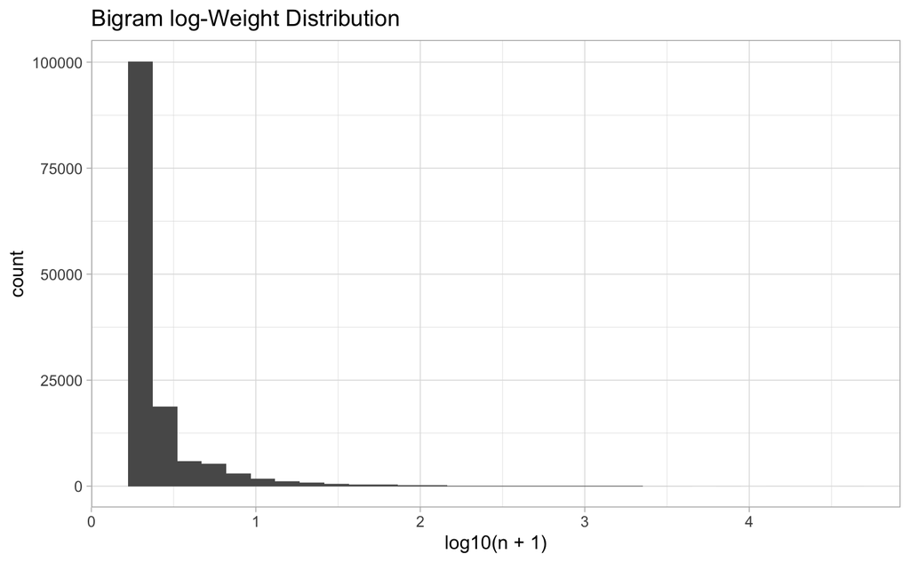

```r
bigram_count %>%
  ggplot(mapping = aes(log10(n+1))) +
  theme_light() +
  geom_histogram() +
  labs(title = "Bigram log-Weight Distribution")
```

This distribution shows most words have been repeated less than 10 times, and very few words used more than 100.

#### Bigram Count Network

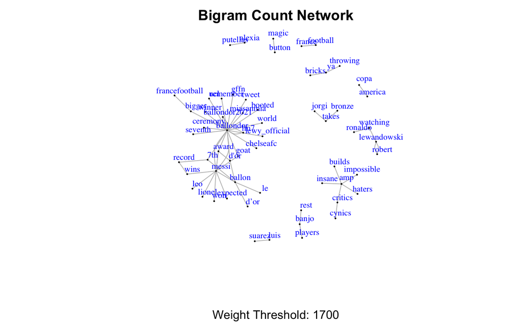

```r
threshold <- 1700

network <-  bigram_count %>%
  # filtered out the words used less than the threshold
  filter(n > threshold) %>%
  # For visualization purposes I scaled by 2000
  mutate(n = n/2000) %>%
  graph_from_data_frame(directed = FALSE)

# plot the network
plot(
  network,
  vertex.size = 1,
  vertex.label.color = 'blue',
  vertex.label.cex = 0.7,
  vertex.label.dist = 1,
  edge.color = 'gray',
  main = 'Bigram Count Network',
  sub = glue('Weight Threshold: {threshold}'),
  alpha = 50
)
```

This fascinating network shows which word has the most connections by which words. “Ballondor” and “Messi” have the most connections among the words. Ronaldo and Lewandowski have a connection with watching, which implied that they were watching Lionel Messi winning the award. 😁